# Google Capstone - Cyclistic Bike Share Case Study

Nana Asare

## SCENARIO

You are a junior data analyst working in the marketing analyst team at Cyclistic, a bike-share company in Chicago. The director of marketing believes the company’s future success depends on maximizing the number of annual memberships. Therefore, your team wants to understand how casual riders and annual members use Cyclistic bikes differently. From these insights, your team will design a new marketing strategy to convert casual riders into annual members. But first, Cyclistic executives must approve your recommendations, so they must be backed up with compelling data insights and professional data visualizations.

## KEY STAKEHOLDERS

- Lily Moreno: The director of marketing and your manager. Moreno is responsible for the development of campaigns and initiatives to promote the bike-share program. These may include email, social media, and other channels.
- Cyclistic marketing analytics team: A team of data analysts who are responsible for collecting, analyzing, and reporting data that helps guide Cyclistic marketing strategy. You joined this team six months ago and have been busy learning about Cyclistic’s mission and business goals — as well as how you, as a junior data analyst, can help Cyclistic achieve them.
- Cyclistic executive team: The notoriously detail-oriented executive team will decide whether to approve the recommended marketing program.

## 1. ASK

Business Task: Design a marketing campaign for Cyclistic aimed at increasing the number of annual members.

To begin addressing the business task we have to consider our target audience. In this case we want to convert casual riders of Cyclistic in to annual members. To do this we will examine how causal riders use Cyclistic differently from annual members.

## 2. PREPARE

For my analysis, I downloaded 12 months of data from June 2021 to May 2022. I stored the data in a file on my laptop and imported the files in to RStudio. The data comes from a public data set and is made available by Motivate International Inc. The data set can be accessed [here](https://divvy-tripdata.s3.amazonaws.com/index.html).

## 3. PROCESS

The files I downloaded were too large to import in to Google Sheets, so I imported the data into RStudio. I started by installing and downloading the R packages I’ll need to process and clean the data.

```r
#download packages
library(tidyverse)
library(janitor)
library(scales)
library(skimr)
```

I read in the files using readr() function which is part of the tidyverse package. All 12 data sets were read in to one data frame named bike_share_df. Checking the column names and the dimensions of the data frame gave me a good overview of the data I’d be working with. This initial data frame has 5,860,776 rows and 14 columns.

```r
#clear the environment
rm(list=ls())

#import files
list_of_files <- list.files(path = "C:/Users/Nana/r_scripts/Coursera/GDAPC/Course_8/bike_data/data",
                            recursive = TRUE,
                            pattern = "\\.csv$",
                            full.names = TRUE)

#combine 12 data sets into one data frame
bike_share_df <- readr::read_csv(list_of_files, id = "file_name")
colnames(bike_share_df)
```

```
##  [1] "file_name"          "ride_id"            "rideable_type"
##  [4] "started_at"         "ended_at"           "start_station_name"
##  [7] "start_station_id"   "end_station_name"   "end_station_id"
## [10] "start_lat"          "start_lng"          "end_lat"
## [13] "end_lng"            "member_casual"
```

```r
dim(bike_share_df)
```

```
## [1] 5860776      14
```

From the output of the colnames() function, I saw that I’d created a new column called “file_name”. This column did not contain useful information so I decided to remove it using the select() function. Now the dimensions of data frame are 5,860,776 rows and 13 columns.

```r
#remove the file_name column
bike_share <- select(bike_share_df, -file_name)
dim(bike_share)
```

```
## [1] 5860776      13
```

Next, I used the remove_empty() function to remove any empty rows or columns in the data frame. The dimensions of bike_share_df after this call remained the same, so there were no completely empty rows or columns. After this, I used the skim_without_charts() function to get a summary of the bike_share_df.

According to the output, there is missing data in 6 columns: -start_station_name: NAs - 823167, completion rate - 86% -start_station_id: NAs - 823164, completion rate - 86% -end_station_name: NAs - 878338, completion rate - 85% -end_station_id: NAs - 878338, completion rate - 85% -end_lat: NAs - 5036, completion rate - 99.9% -end_lag: NAs - 5036, completion rate - 99.9%

```r
#remove empty rows and columns
bike_share <- remove_empty(bike_share, which = c("rows", "cols"))
dim(bike_share)
```

```
## [1] 5860776      13
```

```r
#summary of the data
skim_without_charts(bike_share)
```

Data summary

| Name | bike_share |
| --- | --- |
| Number of rows | 5860776 |
| Number of columns | 13 |
| _______________________ |  |
| Column type frequency: |  |
| character | 7 |
| numeric | 4 |
| POSIXct | 2 |
| ________________________ |  |
| Group variables | None |

**Variable type: character**

| skim_variable | n_missing | complete_rate | min | max | empty | n_unique | whitespace |
| --- | --- | --- | --- | --- | --- | --- | --- |
| ride_id | 0 | 1.00 | 16 | 16 | 0 | 5860776 | 0 |
| rideable_type | 0 | 1.00 | 11 | 13 | 0 | 3 | 0 |
| start_station_name | 823167 | 0.86 | 3 | 53 | 0 | 1105 | 0 |
| start_station_id | 823164 | 0.86 | 3 | 44 | 0 | 1063 | 0 |
| end_station_name | 878338 | 0.85 | 9 | 53 | 0 | 1112 | 0 |
| end_station_id | 878338 | 0.85 | 3 | 44 | 0 | 1068 | 0 |
| member_casual | 0 | 1.00 | 6 | 6 | 0 | 2 | 0 |

**Variable type: numeric**

| skim_variable | n_missing | complete_rate | mean | sd | p0 | p25 | p50 | p75 | p100 |
| --- | --- | --- | --- | --- | --- | --- | --- | --- | --- |
| start_lat | 0 | 1 | 41.90 | 0.05 | 41.64 | 41.88 | 41.90 | 41.93 | 45.64 |
| start_lng | 0 | 1 | -87.65 | 0.03 | -87.84 | -87.66 | -87.64 | -87.63 | -73.80 |
| end_lat | 5036 | 1 | 41.90 | 0.05 | 41.39 | 41.88 | 41.90 | 41.93 | 42.17 |
| end_lng | 5036 | 1 | -87.65 | 0.03 | -88.97 | -87.66 | -87.64 | -87.63 | -87.49 |

**Variable type: POSIXct**

| skim_variable | n_missing | complete_rate | min | max | median | n_unique |
| --- | --- | --- | --- | --- | --- | --- |
| started_at | 0 | 1 | 2021-06-01 00:00:38 | 2022-05-31 23:59:56 | 2021-09-23 17:33:23 | 4896834 |
| ended_at | 0 | 1 | 2021-06-01 00:06:22 | 2022-06-02 11:35:01 | 2021-09-23 17:49:29 | 4893478 |

Next, I used the lubridate package, which is part of the tidyverse package, to parse the data in the started_at and ended_at columns. After the data was parsed I created new columns to use in my analysis.

```r
#parse date-time columns
bike_share$started_at <- lubridate::ymd_hms(bike_share$started_at)
bike_share$ended_at <- lubridate::ymd_hms(bike_share$ended_at)

#create new start and end hours columns
bike_share$start_hour <- lubridate::hour(bike_share$started_at)
bike_share$end_hour <- lubridate::hour(bike_share$ended_at)

#create new trip length columns; hours and minutes
bike_share$trip_len_hrs <- difftime(bike_share$ended_at, bike_share$started_at, units="hours")
bike_share$trip_len_mins <- difftime(bike_share$ended_at, bike_share$started_at, units="mins")

skim_without_charts(bike_share)
```

Data summary

| Name | bike_share |
| --- | --- |
| Number of rows | 5860776 |
| Number of columns | 17 |
| _______________________ |  |
| Column type frequency: |  |
| character | 7 |
| difftime | 2 |
| numeric | 6 |
| POSIXct | 2 |
| ________________________ |  |
| Group variables | None |

**Variable type: character**

| skim_variable | n_missing | complete_rate | min | max | empty | n_unique | whitespace |
| --- | --- | --- | --- | --- | --- | --- | --- |
| ride_id | 0 | 1.00 | 16 | 16 | 0 | 5860776 | 0 |
| rideable_type | 0 | 1.00 | 11 | 13 | 0 | 3 | 0 |
| start_station_name | 823167 | 0.86 | 3 | 53 | 0 | 1105 | 0 |
| start_station_id | 823164 | 0.86 | 3 | 44 | 0 | 1063 | 0 |
| end_station_name | 878338 | 0.85 | 9 | 53 | 0 | 1112 | 0 |
| end_station_id | 878338 | 0.85 | 3 | 44 | 0 | 1068 | 0 |
| member_casual | 0 | 1.00 | 6 | 6 | 0 | 2 | 0 |

**Variable type: difftime**

| skim_variable | n_missing | complete_rate | min | max | median | n_unique |
| --- | --- | --- | --- | --- | --- | --- |
| trip_len_hrs | 0 | 1 | -3482 secs | 3356649 secs | 680 secs | 24942 |
| trip_len_mins | 0 | 1 | -3482 secs | 3356649 secs | 680 secs | 24942 |

**Variable type: numeric**

| skim_variable | n_missing | complete_rate | mean | sd | p0 | p25 | p50 | p75 | p100 |
| --- | --- | --- | --- | --- | --- | --- | --- | --- | --- |
| start_lat | 0 | 1 | 41.90 | 0.05 | 41.64 | 41.88 | 41.90 | 41.93 | 45.64 |
| start_lng | 0 | 1 | -87.65 | 0.03 | -87.84 | -87.66 | -87.64 | -87.63 | -73.80 |
| end_lat | 5036 | 1 | 41.90 | 0.05 | 41.39 | 41.88 | 41.90 | 41.93 | 42.17 |
| end_lng | 5036 | 1 | -87.65 | 0.03 | -88.97 | -87.66 | -87.64 | -87.63 | -87.49 |
| start_hour | 0 | 1 | 14.21 | 5.07 | 0.00 | 11.00 | 15.00 | 18.00 | 23.00 |
| end_hour | 0 | 1 | 14.35 | 5.16 | 0.00 | 11.00 | 15.00 | 18.00 | 23.00 |

**Variable type: POSIXct**

| skim_variable | n_missing | complete_rate | min | max | median | n_unique |
| --- | --- | --- | --- | --- | --- | --- |
| started_at | 0 | 1 | 2021-06-01 00:00:38 | 2022-05-31 23:59:56 | 2021-09-23 17:33:23 | 4896834 |
| ended_at | 0 | 1 | 2021-06-01 00:06:22 | 2022-06-02 11:35:01 | 2021-09-23 17:49:29 | 4893478 |

Finally, I removed any NAs, duplicates and negative trip lengths. That brought the total number of observations to 4,667,073 which is a large enough data set to analyze.

```r
#final cleaning of the data
#remove NAs
bike_share_na_dup <- drop_na(bike_share)

#remove duplicates
bike_share_na_dup <- distinct(bike_share_na_dup)

#remove negative trip lengths
bike_share_fin <- bike_share_na_dup %>%
                  filter(trip_len_mins>0)
rm(bike_share_na_dup)
```

This is the summary of the final dataset.

```r
skim_without_charts(bike_share_fin)
```

Data summary

| Name | bike_share_fin |
| --- | --- |
| Number of rows | 4667073 |
| Number of columns | 17 |
| _______________________ |  |
| Column type frequency: |  |
| character | 7 |
| difftime | 2 |
| numeric | 6 |
| POSIXct | 2 |
| ________________________ |  |
| Group variables | None |

**Variable type: character**

| skim_variable | n_missing | complete_rate | min | max | empty | n_unique | whitespace |
| --- | --- | --- | --- | --- | --- | --- | --- |
| ride_id | 0 | 1 | 16 | 16 | 0 | 4667073 | 0 |
| rideable_type | 0 | 1 | 11 | 13 | 0 | 3 | 0 |
| start_station_name | 0 | 1 | 3 | 53 | 0 | 1045 | 0 |
| start_station_id | 0 | 1 | 3 | 44 | 0 | 1013 | 0 |
| end_station_name | 0 | 1 | 10 | 53 | 0 | 1054 | 0 |
| end_station_id | 0 | 1 | 3 | 44 | 0 | 1021 | 0 |
| member_casual | 0 | 1 | 6 | 6 | 0 | 2 | 0 |

**Variable type: difftime**

| skim_variable | n_missing | complete_rate | min | max | median | n_unique |
| --- | --- | --- | --- | --- | --- | --- |
| trip_len_hrs | 0 | 1 | 1 secs | 3356649 secs | 696 secs | 22713 |
| trip_len_mins | 0 | 1 | 1 secs | 3356649 secs | 696 secs | 22713 |

**Variable type: numeric**

| skim_variable | n_missing | complete_rate | mean | sd | p0 | p25 | p50 | p75 | p100 |
| --- | --- | --- | --- | --- | --- | --- | --- | --- | --- |
| start_lat | 0 | 1 | 41.90 | 0.04 | 41.65 | 41.88 | 41.90 | 41.93 | 45.64 |
| start_lng | 0 | 1 | -87.64 | 0.02 | -87.83 | -87.66 | -87.64 | -87.63 | -73.80 |
| end_lat | 0 | 1 | 41.90 | 0.04 | 41.65 | 41.88 | 41.90 | 41.93 | 42.17 |
| end_lng | 0 | 1 | -87.64 | 0.02 | -87.83 | -87.66 | -87.64 | -87.63 | -87.53 |
| start_hour | 0 | 1 | 14.21 | 5.03 | 0.00 | 11.00 | 15.00 | 18.00 | 23.00 |
| end_hour | 0 | 1 | 14.37 | 5.12 | 0.00 | 11.00 | 15.00 | 18.00 | 23.00 |

**Variable type: POSIXct**

| skim_variable | n_missing | complete_rate | min | max | median | n_unique |
| --- | --- | --- | --- | --- | --- | --- |
| started_at | 0 | 1 | 2021-06-01 00:00:38 | 2022-05-31 23:59:56 | 2021-09-17 15:21:27 | 4001137 |
| ended_at | 0 | 1 | 2021-06-01 00:08:19 | 2022-06-01 16:45:51 | 2021-09-17 15:41:52 | 3997376 |

## 4. ANALYZE

This pie chart shows the trip distribution per rider type between June 2021 and May 2022. We can see that members made up more of the rides between this time.

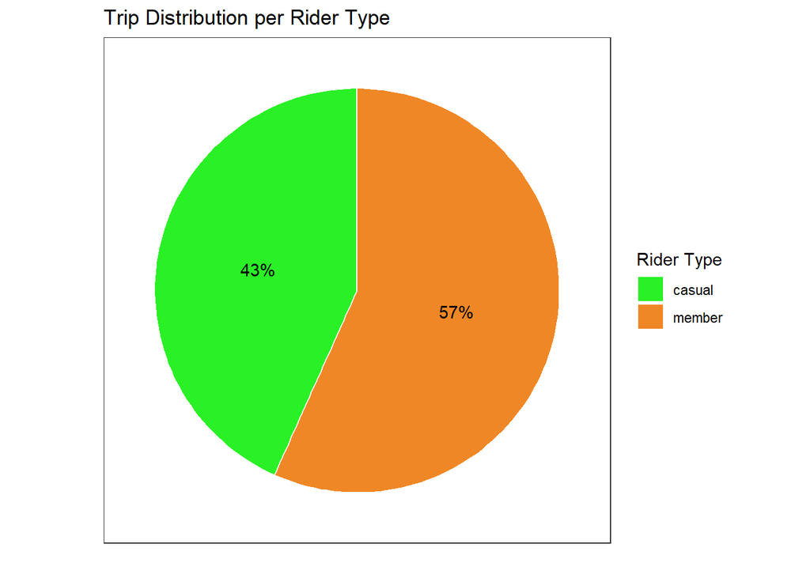

```r
bike_share_fin %>%
  group_by(member_casual) %>%
  summarize(num_trip=n()) %>%
  mutate(percentage=round(num_trip/sum(num_trip),3))%>%
  ggplot(aes(x="", y=percentage, fill=member_casual)) +
  geom_bar(stat="identity", width=1, color="white") +
  scale_fill_manual("Rider Type", values = c("casual" = "#2AF026", "member" = "#F08726"))+
  coord_polar("y", start=0) +
  geom_text(aes(label = percent(percentage)),
            position = position_stack(vjust = 0.5)) +
  labs(x ="", y = "", title = "Trip Distribution per Rider Type", fill="Rider Type") +
  theme_bw()+
  theme(axis.text = element_blank(),
        axis.ticks = element_blank(),
        panel.grid  = element_blank())
```

Looking at riding behavior through different seasons could give insight in to when ridership is at a peak. To create a column with seasonal data, I created a function called season. This function takes the the date from the start_date column and assigns a season to the date depending on where it falls in a range.

```r
#get seasonal data
bike_share_fin$start_date <- as.Date(bike_share_fin$started_at, format = "%Y-%m-%d")
season <- function(date) {
  SS <- as.Date("2021-6-20", format = "%Y-%m-%d") # Summer Solstice
  FE <- as.Date("2021-9-22",  format = "%Y-%m-%d") # Fall Equinox
  WS <- as.Date("2021-12-21",  format = "%Y-%m-%d") # Winter Solstice
  SE <- as.Date("2022-3-20",  format = "%Y-%m-%d") # Spring Equinox

  # convert the date for any year
  d <- as.Date(strftime(date, format="%Y-%m-%d"))

  ifelse(d >= SS & d < FE, "Summer",
          ifelse(d >= FE & d < WS, "Fall",
                  ifelse(d >= WS & d < SE, "Winter", "Spring")))
}
bike_share_fin$seasons <- season(bike_share_fin$start_date)
```

With this seasonal data, I looked at the distribution of ridership for each rider type.

For members, ridership is highest in the Summer followed by Spring then Fall.

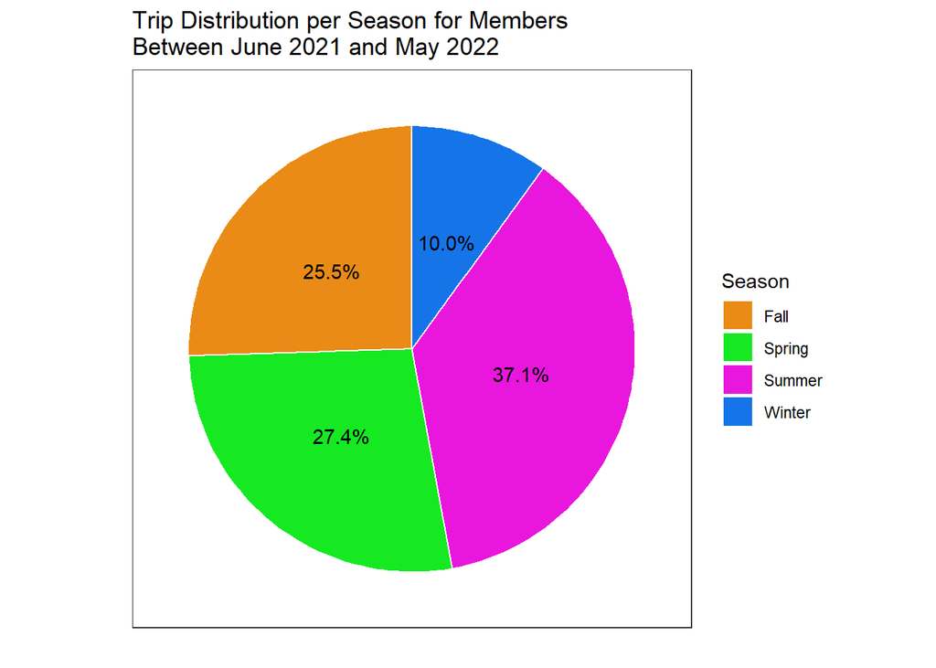

```r
#members
bike_share_fin %>%
  filter(member_casual=="member") %>%
  group_by(seasons) %>%
  summarize(num_trips=n()) %>%
  mutate(percentage=round(num_trips/sum(num_trips),3))%>%
  ggplot(aes(x="", y=percentage, fill=seasons)) +
  geom_bar(stat="identity", width=1, color="white") +
  coord_polar("y", start=0) +
  geom_text(aes(label = percent(percentage)),
            position = position_stack(vjust = 0.5)) +
  labs(x ="", y = "", title = "Trip Distribution per Season for Members \nBetween June 2021 and May 2022", fill="Season") +
  scale_fill_manual("Season", values = c("Fall" = "#E98B16", "Spring" = "#16E922", "Summer"="#E916DD", "Winter"="#1674E9"))+
  theme_bw()+
  theme(axis.text = element_blank(),
        axis.ticks = element_blank(),
        panel.grid  = element_blank())
```

The results for casual riders are similar in rank, but the percentages are significantly different. The Summer sees 50.3% of casual ridership, while the Spring sees 27.6% of the years ridership and the Fall sees 18.1% of the ridership.

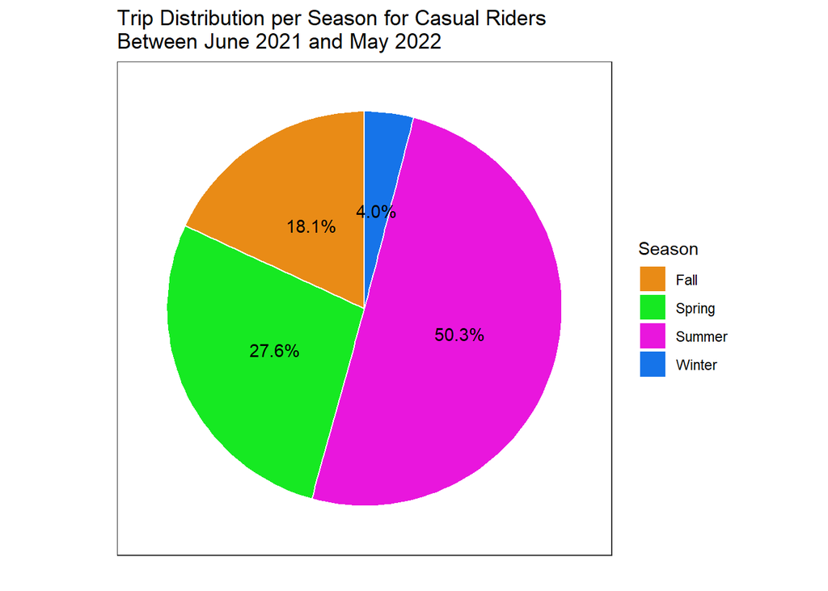

```r
#casual
bike_share_fin %>%
  filter(member_casual=="casual") %>%
  group_by(seasons) %>%
  summarize(num_trips=n()) %>%
  mutate(percentage=round(num_trips/sum(num_trips),3))%>%
  ggplot(aes(x="", y=percentage, fill=seasons)) +
  geom_bar(stat="identity", width=1, color="white") +
  coord_polar("y", start=0) +
  geom_text(aes(label = percent(percentage)),
            position = position_stack(vjust = 0.5)) +
  labs(x ="", y = "", title = "Trip Distribution per Season for Casual Riders \nBetween June 2021 and May 2022", fill="Season") +
  scale_fill_manual("Season", values = c("Fall" = "#E98B16", "Spring" = "#16E922", "Summer"="#E916DD", "Winter"="#1674E9"))+
  theme_bw()+
  theme(axis.text = element_blank(),
        axis.ticks = element_blank(),
        panel.grid  = element_blank())
```

These line graphs show the average trip length for each rider type for each month in the 12 month period. The average ride time peaks in June for both rider types. The average trip length is higher for casual riders. This could mean casual riders travel longer distances than members.

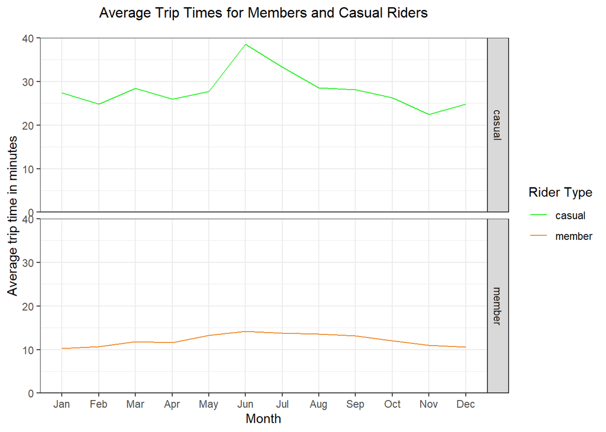

```r
bike_share_fin$start_month <- lubridate::month(bike_share_fin$started_at, abbr = TRUE, label=TRUE)
bike_share_avg_month <- bike_share_fin %>%
  group_by(start_month, member_casual) %>%
  summarise(avg_trip_len = mean(trip_len_mins), across())

bike_share_fin %>%
  group_by(start_month, member_casual) %>%
  summarise(avg_trip_len = mean(trip_len_mins), across()) %>%
  ggplot()+
  geom_line(aes(x = start_month,
                y = avg_trip_len,
                colour=member_casual, group=1)) +
  labs(title = "Average Trip Times for Members and Casual Riders",
       x = "Month",
       y = "Average trip time in minutes",
       colour="Rider Type") +
  scale_color_manual("Rider Type", values = c("casual" = "#2AF026", "member" = "#F08726"))+
  theme_bw()+
  theme(plot.title = element_text(hjust = 0.5, size=12, margin=margin(0,0,15,0)))+
  facet_grid(member_casual ~ .,labeller = labeller(average_ride_length="Average trip time in minutes", start_month = "Month"))+
  scale_y_continuous(expand = c(0, 0), limits = c(0, 40))
```

During what could be considered off seasons, the average trip length drops for members in the Fall and Winter. Which makes sense. Members who need to travel longer distances will probably seek alternative transportation during colder months.

```r
library(geosphere)
```

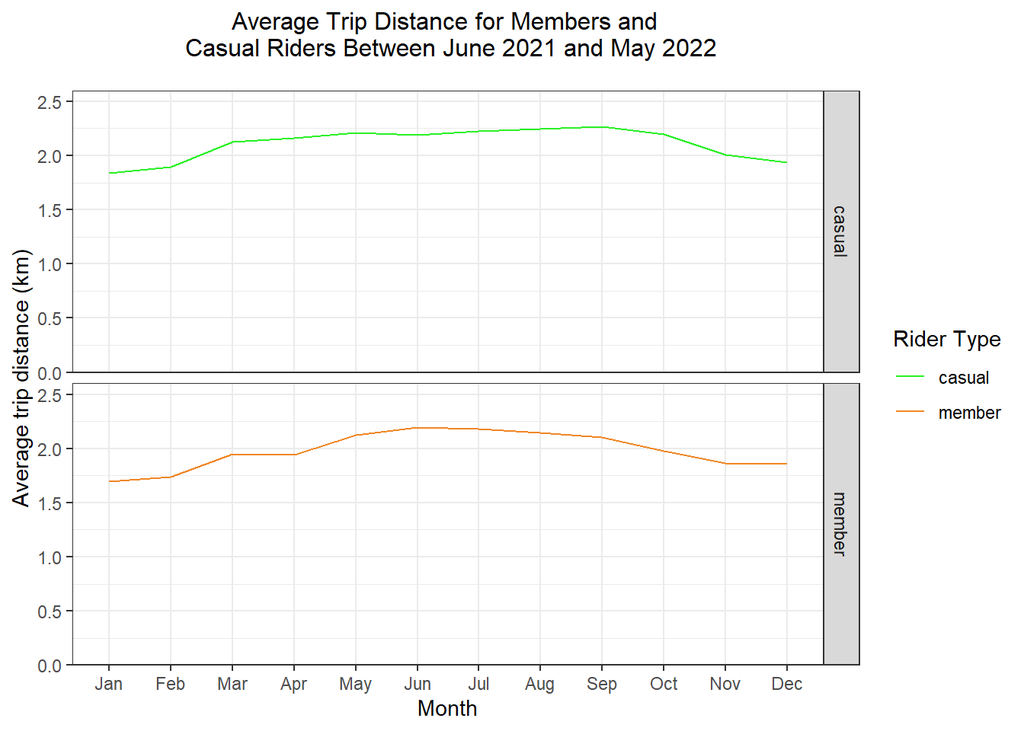

```r
bike_share_fin$distance_km <-distHaversine(cbind(bike_share_fin$start_lng, bike_share_fin$start_lat), cbind(bike_share_fin$end_lng, bike_share_fin$end_lat))/1000

bike_share_fin %>%
  group_by(member_casual, start_month) %>%
  summarize(avg_dist_km=mean(distance_km)) %>%
  ggplot() +
  geom_line(aes(x = start_month,
                y = avg_dist_km,
                colour=member_casual, group =1)) +
  labs(title = "Average Trip Distance for Members and \n Casual Riders Between June 2021 and May 2022",
       x = "Month",
       y = "Average trip distance (km)",
       colour="Rider Type") +
  scale_color_manual("Rider Type", values = c("casual" = "#2AF026", "member" = "#F08726"))+
  theme_bw() +
  theme(plot.title = element_text(hjust = 0.5, size=12, margin=margin(0,0,15,0)))+
  facet_grid(member_casual ~ .,labeller = labeller(average_distance_km="Average trip distance (km)", start_month = "Month"))+
  scale_y_continuous(expand = c(0, 0), limits = c(0, 2.6))
```

## 5. SHARE

From this data we can see even though annual Member riders make up a majority of the ridership, Casual riders use the bikes for longer trips and longer times compared to annual Members. Summer and Spring are the most popular seasons for ridership between the different rider types.

## 6. ACT

An action the Cyclistic team could take to increase annual memberships would be to offer seasonal memberships during the Spring and Summer. This would capture long-term tourists traveling for a season or two and increase membership during active months.